# Scenario: Haulout Reduction @ Ballard

Describing the model run where the total pool of pinnipeds is reduced through removals on the haulouts

October 23, 2024

### The Narrative

This Model Run is for a scenario where some kind of removals or harvest or displacement has happened on the haulouts that make up the source pool for harbor seals at the Locks (Shilshole and Elliot Bay marinas mainly). This action decreases the overall abundance of harbor seals in the system.

### Run the Model

```r
reduction <- 0.5
num_seals <- num_seals * reduction
```

### Description of Parameterization

In this scenario the source pool of harbor seals is decreased to 75 to simulate removals or disturbance on the main marina haulouts that they use to access the Locks. This is a 50% decrease in harbor seals in the source population. As a result, seal presence at the Locks is reduced compared to the base run.

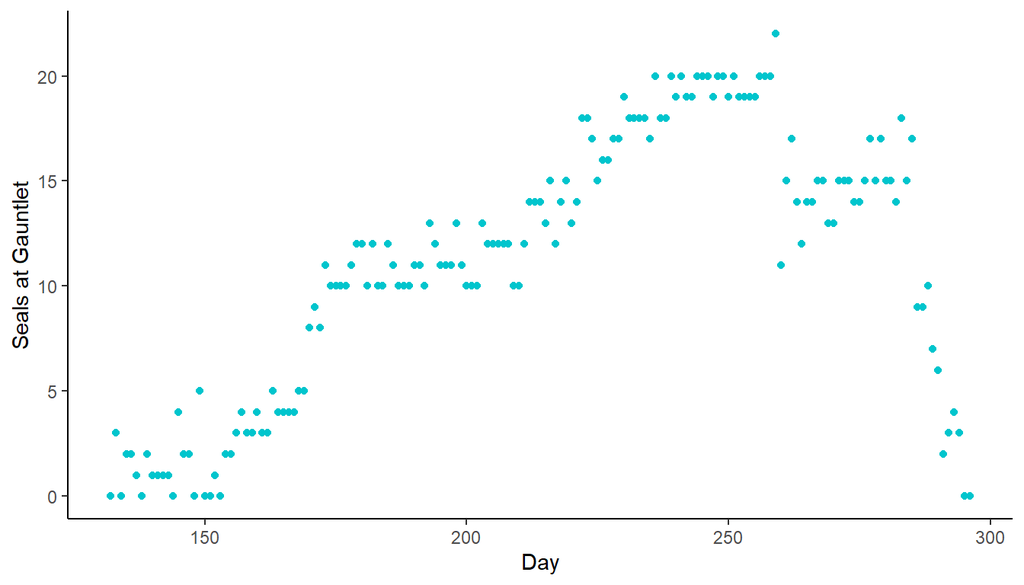

In this scenario, incidental take related to the Coho fishery still occurs and results in a low level of harbor seal take, which impacts their behavior and presence at the Gauntlet at the end of the model run.

| Pv | Ej | Zc |
| --- | --- | --- |
| 1 | 0 | 0 |

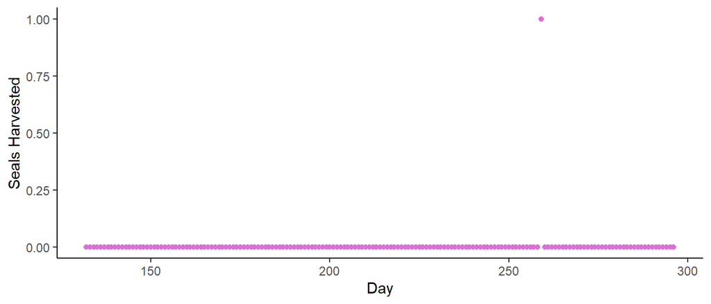

However, overall salmon consumption is not much lower than in the boat-based harvest scenario, even for the Sockeye run. This implies that inter-specific competition may be important, and seal presence may have to be dramatically reduced in order to see positive impacts for salmon.

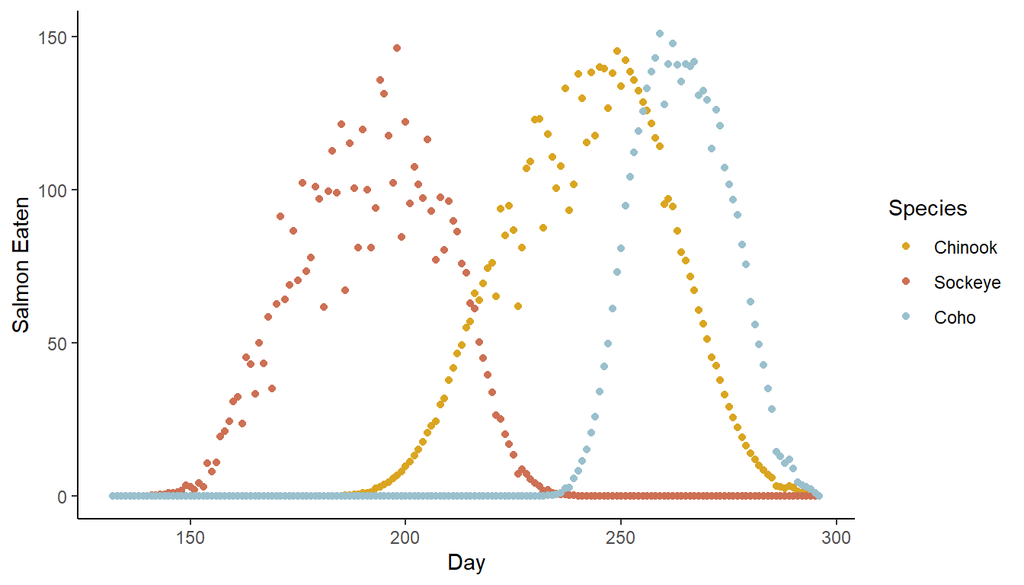

### Salmon Response

The fate of the sockeye, Chinook, and coho are as follows under this parameterization:

|  | Sockeye | Chinook | Coho |
| --- | --- | --- | --- |
| Escape | 63623 | 1959 | 8777 |
| Catch | 0 | 750 | 4024 |
| Predated | 5229 | 6564 | 4332 |

### Parameter Table

|  | Value |
| --- | --- |
| num_seals | 75.0000000 |
| reduction | 0.5000000 |
| num_seals_2_copy | 37.5000000 |
| sockeye_escape_rate | 0.3333333 |
| chinook_escape_rate | 0.0151515 |
| coho_escape_rate | 0.1000000 |
| min_fishers | 13.0000000 |
| max_fishers | 25.0000000 |
| fishery_open | 253.0000000 |
| fishery_close | 321.0000000 |